# Predicting German House Prices using Weighted Linear Regression

# About this project

Projects using linear regression or random forests to predict housing prices are quite common additions to data science and analytics portfolios, but many of these use North American datasets. I live in Germany, so I decided to use a German dataset provided by Kaggle user Erdogan Seref, who obtained this data by scraping the website ImmoScout24 on the 14th of July 2020 (URL: https://www.kaggle.com/scriptsultan/german-house-prices?select=germany_housing_data_14.07.2020.csv.

# Load required packages

```r
library(tidyverse)
library(ggplot2)
library(here)
#library(corrplot)
#library(ggcorrplot)
library(gridExtra)
#library(Hmisc)
#library(regclass)
#library(car)
#library(arm)
#library(caret)

my_theme <- theme(axis.line.x.bottom = element_line(size = 0.25),
                  axis.line.y.left = element_line(size = 0.25),
                  panel.background = element_rect(fill = "white"),
                  panel.grid = element_blank())

theme_set(my_theme)
```

# Examine and prepare data

To start with, let’s take a look at the data.

```r
data <- read_csv(here("machine-learning", "germany_housing_data_14.07.2020.csv"))
data <- data %>% mutate_if(is.character, as.factor) %>% distinct() # transform charactors to factors and drop duplicated values
glimpse(data)
```

```
Rows: 10,552
Columns: 26
$ X1                      <dbl> 0, 1, 2, 3, 4, 5, 6, 7, 8, 9, 10, 11, 12, 13~
$ Price                   <dbl> 498000, 495000, 749000, 259000, 469000, 1400~
$ Type                    <fct> Multiple dwelling, Mid-terrace house, Farmho~
$ Living_space            <dbl> 106.00, 140.93, 162.89, 140.00, 115.00, 310.~
$ Lot                     <dbl> 229, 517, 82, 814, 244, 860, 5300, 406, 973,~
$ Usable_area             <dbl> NA, 20.00, 37.62, NA, NA, 100.00, 163.16, 11~
$ Free_of_Relation        <fct> "01.10.2020", "01.01.2021", "01.07.2020", "n~
$ Rooms                   <dbl> 5.5, 6.0, 5.0, 4.0, 4.5, 8.0, 13.0, 10.0, 10~
$ Bedrooms                <dbl> 3, 3, 3, NA, 2, NA, NA, NA, 4, NA, 4, 9, 4, ~
$ Bathrooms               <dbl> 1, 2, 2, 2, 1, NA, 4, NA, 4, NA, 2, 3, NA, 2~
$ Floors                  <dbl> 2, NA, 4, 2, NA, 3, NA, 3, 2, 3, 3, 3, NA, 3~
$ Year_built              <dbl> 2005, 1994, 2013, 1900, 1968, 1969, 2004, 19~
$ Furnishing_quality      <fct> normal, basic, NA, basic, refined, basic, ba~
$ Year_renovated          <dbl> NA, NA, NA, 2000, 2019, NA, NA, NA, 2015, NA~
$ Condition               <fct> modernized, modernized, dilapidated, fixer-u~
$ Heating                 <fct> central heating, stove heating, stove heatin~
$ Energy_source           <fct> "Gas", NA, "Fernwärme, Bioenergie", "Strom",~
$ Energy_certificate      <fct> available, not required by law, available, a~
$ Energy_certificate_type <fct> demand certificate, NA, demand certificate, ~
$ Energy_consumption      <dbl> NA, NA, NA, NA, NA, NA, 35.9, NA, 183.1, NA,~
$ Energy_efficiency_class <fct> D, NA, B, G, F, NA, A, E, F, D, NA, D, NA, N~
$ State                   <fct> Baden-Württemberg, Baden-Württemberg, Baden-~
$ City                    <fct> Bodenseekreis, Konstanz (Kreis), Esslingen (~
$ Place                   <fct> "Bermatingen", "Engen", "Ostfildern", "Bonnd~
$ Garages                 <dbl> 2, 7, 1, 1, 1, 2, 7, 2, 8, 12, 2, 4, 2, 1, 2~
$ Garagetype              <fct> Parking lot, Parking lot, Garage, Garage, Ga~
```

Next, we should see summary statistics and count missing values for each variable:

```r
summary(data)
```

```
       X1            Price                         Type       Living_space
 Min.   :    0   Min.   :       0   Mid-terrace house:4324   Min.   :   0.0
 1st Qu.: 2638   1st Qu.:  250000   Duplex           :2127   1st Qu.: 130.0
 Median : 5276   Median :  405215   Single dwelling  :1169   Median : 176.8
 Mean   : 5276   Mean   :  556685   Farmhouse        : 573   Mean   : 216.7
 3rd Qu.: 7913   3rd Qu.:  655000   Villa            : 396   3rd Qu.: 250.0
 Max.   :10551   Max.   :13000000   (Other)          :1561   Max.   :5600.0
                                    NA's             : 402
      Lot            Usable_area              Free_of_Relation
 Min.   :     0.0   Min.   :   0.0   nach Absprache   :1383
 1st Qu.:   370.0   1st Qu.:  48.0   sofort           :1258
 Median :   656.5   Median :  80.0   nach Vereinbarung: 986
 Mean   :  1491.7   Mean   : 134.3   ab sofort        : 659
 3rd Qu.:  1047.0   3rd Qu.: 150.2   Nach Vereinbarung: 151
 Max.   :547087.0   Max.   :4034.0   (Other)          :2544
                    NA's   :4984     NA's             :3571
     Rooms            Bedrooms       Bathrooms          Floors
 Min.   :  1.000   Min.   : 0.00   Min.   : 0.000   Min.   : 0.000
 1st Qu.:  5.000   1st Qu.: 3.00   1st Qu.: 1.000   1st Qu.: 2.000
 Median :  6.000   Median : 4.00   Median : 2.000   Median : 2.000
 Mean   :  7.389   Mean   : 4.17   Mean   : 2.309   Mean   : 2.284
 3rd Qu.:  8.000   3rd Qu.: 5.00   3rd Qu.: 3.000   3rd Qu.: 3.000
 Max.   :170.000   Max.   :61.00   Max.   :44.000   Max.   :13.000
                   NA's   :3674    NA's   :1801     NA's   :2664
   Year_built   Furnishing_quality Year_renovated       Condition
 Min.   :1300   basic  :2690       Min.   :1900   modernized :4440
 1st Qu.:1935   luxus  : 488       1st Qu.:2006   refurbished:1305
 Median :1971   normal :3734       Median :2015   dilapidated:1167
 Mean   :1959   refined: 914       Mean   :2011   maintained :1069
 3rd Qu.:1996   NA's   :2726       3rd Qu.:2018   renovated  :1034
 Max.   :2022                      Max.   :2206   (Other)    :1214
 NA's   :694                       NA's   :5203   NA's       : 323
               Heating           Energy_source
 stove heating     :5976   Gas          :4528
 heat pump         : 985   Öl           :2574
 central heating   : 894   Strom        : 555
 oil heating       : 746   Fernwärme    : 180
 underfloor heating: 418   Erdgas leicht: 175
 (Other)           : 949   (Other)      :1313
 NA's              : 584   NA's         :1227
```

[output cut: 17 more lines]

```
 Hannover (Kreis)     :  107   Innenstadt:   32   Min.   : 1.000
 Nordfriesland (Kreis):   95   Falkensee :   28   1st Qu.: 1.000
 Rhein-Neckar-Kreis   :   95   Stadtmitte:   20   Median : 2.000
 Wetteraukreis        :   85   Hameln    :   19   Mean   : 2.699
 Rhein-Sieg-Kreis     :   76   Homburg   :   19   3rd Qu.: 3.000
 (Other)              :10093   (Other)   :10144   Max.   :70.000
 NA's                 :    1   NA's      :  290   NA's   :1960
                   Garagetype
 Garage                 :4412
 Outside parking lot    :1695
 Parking lot            :1603
 Carport                : 732
 Underground parking lot:  96
 (Other)                :  54
 NA's                   :1960
```

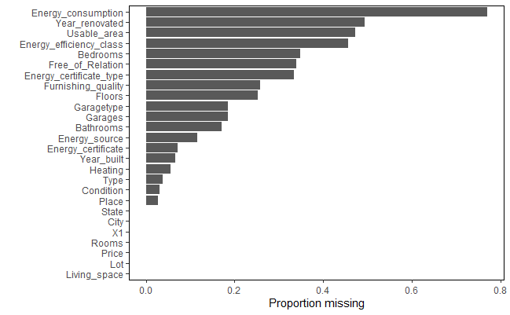

```r
missing <- as.data.frame(map(data, ~sum(is.na(.))/10552)) # calculate proportion of missing values in each column
missing <- missing %>% pivot_longer(names_to = "var", cols = c(1:26))

# plot proportion of missing values for each variable
missing %>% ggplot(aes(x = fct_reorder(var, value), y = value)) +
  geom_col() +
  coord_flip() +
  xlab("") +
  ylab("Proportion missing")
```

### Looking for outliers

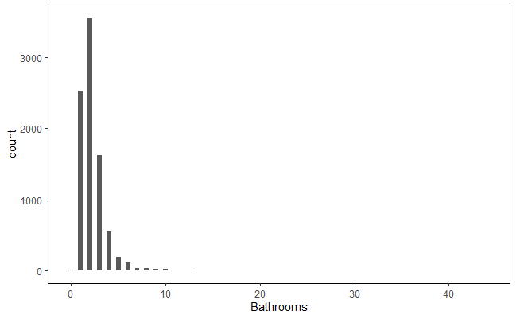

```r
data %>% ggplot(aes(x = Bathrooms)) +
  geom_histogram(binwidth = 0.5)
```

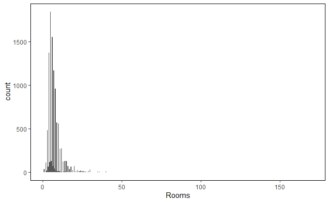

```r
data %>% ggplot(aes(x = Rooms)) +
  geom_histogram(binwidth = 0.5)
```

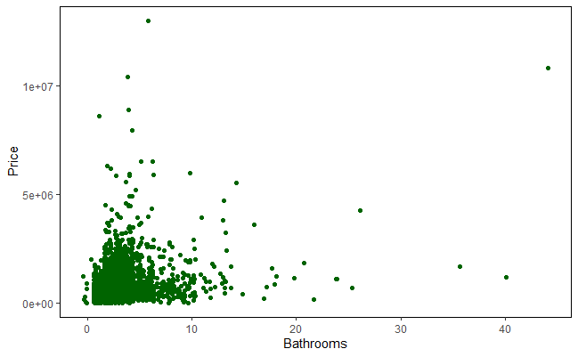

```r
data %>% ggplot(aes(x = Bathrooms, y = Price)) +
  geom_jitter(colour = "darkgreen")
```

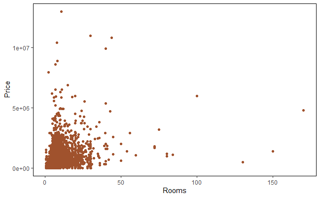

```r
data %>% ggplot(aes(x = Rooms, y = Price)) +
  geom_jitter(colour = "sienna")
```

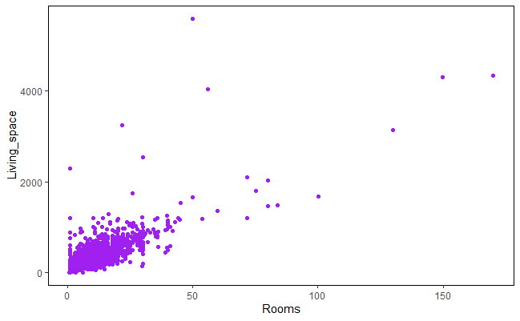

```r
data %>% ggplot(aes(x = Rooms, y = Living_space)) +
  geom_jitter(colour = "purple")
```

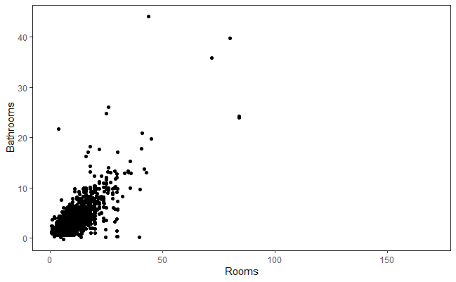

```r
data %>% ggplot(aes(x = Rooms, y = Bathrooms)) +
  geom_jitter()
```

Let’s see what type of properties have such high numbers of rooms.

```r
data_high <- data %>% filter(Rooms >= 50)

data_high %>% count(Type)
```

| Type | n |
| --- | --- |
| Bungalow | 1 |
| Castle | 1 |
| Duplex | 11 |
| Residential property | 1 |
| NA | 2 |

```r
data %>% count(Type)
```

| Type | n |
| --- | --- |
| Bungalow | 249 |
| Castle | 7 |
| Corner house | 201 |
| Duplex | 2127 |
| Farmhouse | 573 |
| Mid-terrace house | 4324 |
| Multiple dwelling | 379 |
| Residential property | 367 |
| Single dwelling | 1169 |
| Special property | 358 |

[output cut: 2 more lines]

It’s very strange to see a Bungalow with more than 50 rooms. Let’s take a closer look:

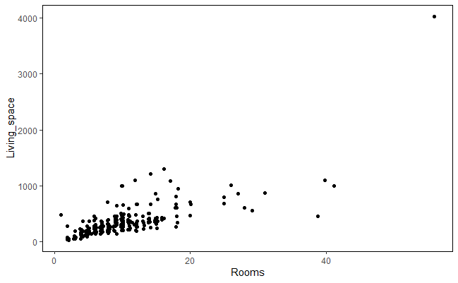

```r
data %>% filter(Type == "Bungalow") %>%
  ggplot(aes(x = Rooms, y = Living_space)) +
  geom_jitter()
```

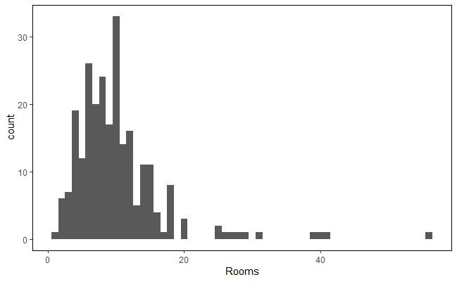

```r
data %>% filter(Type == "Bungalow") %>%
  ggplot(aes(x = Rooms)) +
  geom_histogram(binwidth = 1)
```

It looks like there are some really big bungalows out there. It makes me wonder whether some of these entries could be mislabeled, but short of checking all the corresponding listings there’s nothing I can do about that. There also don’t seem to be any data points which are clearly wrong, so I won’t remove any.

### Handling missing data

Missing data can be replaced if there isn’t too much missing and some reasonable methods to do it are possible (e.g., replacing some missing values with the mean or mode of the variable), but other times it’s not reasonable to do so and they should just be deleted.

We can see that `Energy_consumption` is missing almost 80% of its data, so this likely won’t be useful for any analyses. The alternative, `Energy_efficiency_class` is also missing quite a lot of data (almost 50%) so it’s not likely we’ll be able to reliably use variables related to energy consumption and efficiency to predict sales prices here. Trying to replace the missing data would be too hard so we’ll just ignore these variables.

Sadly, there are no definite rules for how to handle missing data or outliers - this depends on the specific data and goals of your analysis. For the purpose of this project, I have decided not to attempt to replace missing data in variables where more than 40% of it is missing. That means I will ignore the following variables for my analysis: - Energy_consumption - Year_renovated - Usable_area - Energy_efficiency_class

```r
data <- data %>% dplyr::select(-c(Energy_consumption, Year_renovated, Usable_area, Energy_efficiency_class))
```

Before thinking about imputing missing values, let’s look at correlations between variables in this dataset so we can figure out which variables to keep.

To do this, I’m using a function defined by Catherine Williams in [this](https://towardsdatascience.com/how-to-create-a-correlation-matrix-with-too-many-variables-309cc0c0a57) Medium post. The output is a correlation plot which shows only significant correlations.

|  | Var1 | Var2 | Freq |
| --- | --- | --- | --- |
| 136 | Living_space | Rooms | 0.80353334 |
| 68 | Price | Living_space | 0.44691768 |
| 134 | Price | Rooms | 0.31003605 |
| 23 | X1 | Price | -0.22105438 |
| 92 | Living_space | Lot | 0.10920728 |
| 90 | Price | Lot | 0.10291814 |
| 137 | Lot | Rooms | 0.08498623 |

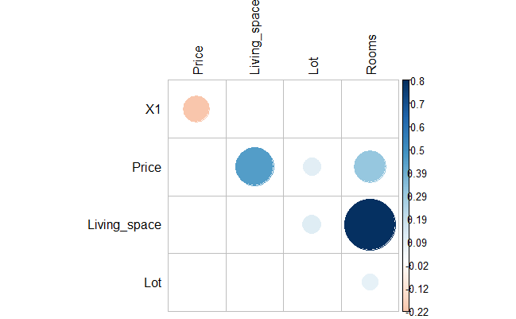

```r
library(corrplot)
corr_simple <- function(data = df,sig = 0.5){
  #convert data to numeric in order to run correlations
  #convert to factor first to keep the integrity of the data - each value will become a number rather than turn into NA
  df_cor <- data %>% mutate_if(is.character, as.factor)
  df_cor <- df_cor %>% mutate_if(is.factor, as.numeric)
  #run a correlation and drop the insignificant ones
  corr <- cor(df_cor)
  #prepare to drop duplicates and correlations of 1
  corr[lower.tri(corr,diag=TRUE)] <- NA
  #drop perfect correlations
  corr[corr == 1] <- NA   #turn into a 3-column table
  corr <- as.data.frame(as.table(corr))
  #remove the NA values from above
  corr <- na.omit(corr)   #select significant values
  corr <- subset(corr, abs(Freq) > sig)
  #sort by highest correlation
  corr <- corr[order(-abs(corr$Freq)),]   #print table
  print(corr)  #turn corr back into matrix in order to plot with corrplot
  mtx_corr <- reshape2::acast(corr, Var1~Var2, value.var="Freq")

  #plot correlations visually
  corrplot(mtx_corr, is.corr=FALSE, tl.col="black", na.label=" ")
}

corr_simple(data, sig = 0.05)
```

Based on this output, it seems that there are 5 variables with significant associations in this dataset: - Price - X1 - Lot - Rooms - Living space

We need to replace missing values in the values that make sense as predictors though.

### Impute missing values

Based on the previous correlation plot, we can assume that most variables are pretty independent of each other, so again, a complicated imputation method is probably overkill. I’m just going to stick with the rule of thumb of replacing numeric values with the mean and categorical values with the mode.

```r
# find mode of each categorical var:
mode <- function(v) {
   uniqv <- unique(v)
   uniqv[which.max(tabulate(match(v, uniqv)))]
}
# check that it works
mode(data$Type)
```

```
[1] Mid-terrace house
11 Levels: Bungalow Castle Corner house Duplex ... Villa
```

```r
# first, for numeric vars only
data <- data %>% mutate(Year_built = replace_na(Year_built, mean(Year_built, na.rm = TRUE)),
                        Garages = replace_na(Garages,  mean(Garages, na.rm = TRUE)),
                        Floors = replace_na(Floors,  mean(Floors, na.rm = TRUE)),
                        Type = replace_na(Type,  mode(Type)),
                        Furnishing_quality = replace_na(Furnishing_quality,  mode(Furnishing_quality)),
                        Condition = replace_na(Condition,  mode(Condition)),
                        Heating = replace_na(Heating,  mode(Heating)),
                        Energy_source = replace_na(Energy_source,  mode(Energy_source)),
                        Energy_certificate = replace_na(Energy_certificate,  mode(Energy_certificate)),
                        Energy_certificate_type = replace_na(Energy_certificate_type,  mode(Energy_certificate_type)),
                        State = replace_na(State,  mode(State)),
                        Garagetype = replace_na(Garagetype,  mode(Garagetype)))






# keep only "relevant" variables for prediction
data_simple <- data %>%
  dplyr::select(-c(City, Free_of_Relation, Rooms, Bedrooms, Bathrooms, Place, City))

#data_simple <- data_simple %>% filter(Price >= 0)
glimpse(data_simple)
```

```
Rows: 10,552
Columns: 16
$ X1                      <dbl> 0, 1, 2, 3, 4, 5, 6, 7, 8, 9, 10, 11, 12, 13~
$ Price                   <dbl> 498000, 495000, 749000, 259000, 469000, 1400~
$ Type                    <fct> Multiple dwelling, Mid-terrace house, Farmho~
$ Living_space            <dbl> 106.00, 140.93, 162.89, 140.00, 115.00, 310.~
$ Lot                     <dbl> 229, 517, 82, 814, 244, 860, 5300, 406, 973,~
$ Floors                  <dbl> 2.000000, 2.283976, 4.000000, 2.000000, 2.28~
$ Year_built              <dbl> 2005, 1994, 2013, 1900, 1968, 1969, 2004, 19~
$ Furnishing_quality      <fct> normal, basic, normal, basic, refined, basic~
$ Condition               <fct> modernized, modernized, dilapidated, fixer-u~
$ Heating                 <fct> central heating, stove heating, stove heatin~
$ Energy_source           <fct> "Gas", "Gas", "Fernwärme, Bioenergie", "Stro~
$ Energy_certificate      <fct> available, not required by law, available, a~
$ Energy_certificate_type <fct> demand certificate, demand certificate, dema~
$ State                   <fct> Baden-Württemberg, Baden-Württemberg, Baden-~
$ Garages                 <dbl> 2.000000, 7.000000, 1.000000, 1.000000, 1.00~
$ Garagetype              <fct> Parking lot, Parking lot, Garage, Garage, Ga~
```

```r
# check if any NAs remain
sum(is.na(data_simple))
```

```
[1] 0
```

# Predict housing prices with linear regression

Split data into train (70%) and test (30%):

```r
set.seed(1)
row.number <- sample(1:nrow(data_simple), 0.7*nrow(data_simple))
train <- data_simple[row.number,]
test <- data_simple[-row.number,]

# check that all factors have the same number of levels between datasets
print("structure train")
```

```
[1] "structure train"
```

```r
str(train)
```

```
tibble [7,386 x 16] (S3: tbl_df/tbl/data.frame)
 $ X1                     : num [1:7386] 1016 8003 4774 10368 9724 ...
 $ Price                  : num [1:7386] 525000 499000 379000 692000 235000 99000 350000 249000 458000 1330000 ...
 $ Type                   : Factor w/ 11 levels "Bungalow","Castle",..: 6 6 6 6 6 4 6 6 1 6 ...
 $ Living_space           : num [1:7386] 230 115 150 350 125 300 170 292 250 254 ...
 $ Lot                    : num [1:7386] 4651 804 830 993 900 ...
 $ Floors                 : num [1:7386] 2 2 2 2 2 ...
 $ Year_built             : num [1:7386] 1963 1953 1980 1997 1996 ...
 $ Furnishing_quality     : Factor w/ 4 levels "basic","luxus",..: 3 3 1 3 3 3 3 3 1 3 ...
 $ Condition              : Factor w/ 10 levels "as new","by arrangement",..: 8 10 8 7 8 6 8 8 6 3 ...
 $ Heating                : Factor w/ 13 levels "central heating",..: 11 11 11 11 11 8 11 11 11 3 ...
 $ Energy_source          : Factor w/ 104 levels "Bioenergie","Erdgas leicht",..: 58 23 23 23 23 23 27 58 23 93 ...
 $ Energy_certificate     : Factor w/ 3 levels "available","available for inspection",..: 1 3 1 1 1 1 1 2 1 1 ...
 $ Energy_certificate_type: Factor w/ 2 levels "consumption certificate",..: 2 2 1 1 1 1 2 2 1 2 ...
 $ State                  : Factor w/ 16 levels "Baden-Württemberg",..: 1 11 9 15 14 16 11 7 12 2 ...
 $ Garages                : num [1:7386] 2.7 2 1 1 2.7 ...
 $ Garagetype             : Factor w/ 7 levels "Car park lot",..: 4 2 4 4 4 5 6 4 2 4 ...
```

```r
print("structure test")
```

```
[1] "structure test"
```

```r
str(test)
```

```
tibble [3,166 x 16] (S3: tbl_df/tbl/data.frame)
 $ X1                     : num [1:3166] 0 9 10 11 12 16 19 22 24 25 ...
 $ Price                  : num [1:3166] 498000 1900000 1750000 470000 475000 979000 359000 625000 650000 430000 ...
 $ Type                   : Factor w/ 11 levels "Bungalow","Castle",..: 7 4 6 4 9 4 9 6 6 5 ...
 $ Living_space           : num [1:3166] 106 787 210 268 124 ...
 $ Lot                    : num [1:3166] 229 933 1460 1511 258 ...
 $ Floors                 : num [1:3166] 2 3 3 3 2.28 ...
 $ Year_built             : num [1:3166] 2005 1920 1939 1976 1989 ...
 $ Furnishing_quality     : Factor w/ 4 levels "basic","luxus",..: 3 1 3 1 1 1 3 3 3 1 ...
 $ Condition              : Factor w/ 10 levels "as new","by arrangement",..: 8 8 8 8 8 8 8 8 8 9 ...
 $ Heating                : Factor w/ 13 levels "central heating",..: 1 11 11 11 5 11 11 9 11 11 ...
 $ Energy_source          : Factor w/ 104 levels "Bioenergie","Erdgas leicht",..: 23 26 58 58 93 23 58 23 58 58 ...
 $ Energy_certificate     : Factor w/ 3 levels "available","available for inspection",..: 1 1 1 1 1 1 1 1 1 1 ...
 $ Energy_certificate_type: Factor w/ 2 levels "consumption certificate",..: 2 2 1 2 2 1 1 1 1 2 ...
 $ State                  : Factor w/ 16 levels "Baden-Württemberg",..: 1 1 1 1 1 1 1 1 1 1 ...
 $ Garages                : num [1:3166] 2 12 2 4 2 ...
 $ Garagetype             : Factor w/ 7 levels "Car park lot",..: 6 6 4 6 6 5 4 5 6 4 ...
```

It’s generally bad practice to automatically include all possible predictors in a model, so let’s use Stepwise Linear Regression to select the features of interest.

```r
library(caret)
# Set seed for reproducibility
set.seed(123)
# Set up repeated k-fold cross-validation
train.control <- trainControl(method = "cv", number = 10)
# Train the model
step.model1 <- train(Price ~., data = train,
                    method = "leapForward",
                    tuneGrid = data.frame(nvmax = 1:16),
                    trControl = train.control
                    )
```

```r
step.model1$results # model comparison
```

|  | nvmax | RMSE | Rsquared | MAE | RMSESD | RsquaredSD | MAESD |
| --- | --- | --- | --- | --- | --- | --- | --- |
| 1 | 1 | 548441.9 | 0.2216646 | 298814.5 | 66536.10 | 0.10388488 | 11586.77 |
| 2 | 2 | 522134.0 | 0.2808200 | 285246.1 | 64781.64 | 0.08071079 | 12385.86 |
| 3 | 3 | 506014.3 | 0.3222816 | 269414.4 | 66109.29 | 0.07846479 | 12806.51 |
| 4 | 4 | 494821.2 | 0.3473179 | 265386.8 | 62464.38 | 0.07133922 | 13014.91 |
| 5 | 5 | 494987.9 | 0.3476471 | 263710.0 | 62465.18 | 0.07070804 | 12857.98 |
| 6 | 6 | 494165.4 | 0.3492984 | 262318.2 | 62214.63 | 0.06907503 | 11942.73 |
| 7 | 7 | 492795.1 | 0.3527527 | 261525.5 | 62134.28 | 0.06678189 | 11352.39 |
| 8 | 8 | 491955.4 | 0.3561806 | 259592.0 | 63634.56 | 0.06756876 | 13874.12 |
| 9 | 9 | 491555.3 | 0.3575165 | 259684.8 | 63555.04 | 0.06590254 | 13868.59 |
| 10 | 10 | 490767.3 | 0.3583179 | 259110.0 | 64123.47 | 0.06518845 | 13146.50 |

[output cut: 6 more lines]

```r
step.model1$bestTune # number of predictors for best model
```

|  | nvmax |
| --- | --- |
| 16 | 16 |

```r
coef(step.model1$finalModel, 16) # coefficients for that model
```

```
                           (Intercept)                                     X1
                         -1.752632e+06                          -3.718844e+01
                             TypeVilla                           Living_space
                          5.697227e+05                           1.209293e+03
                                   Lot                                 Floors
                          7.052853e+00                           6.918512e+04
                            Year_built                Furnishing_qualityluxus
                          1.040708e+03                           5.738147e+05
             Furnishing_qualityrefined           Energy_sourceErdwärme, Solar
                         -1.575264e+05                           6.058390e+04
                Energy_sourceGas, Holz                                Garages
                         -4.461401e+04                          -1.765517e+03
                     GaragetypeCarport      GaragetypeUnderground parking lot
                          1.726439e+04                           5.113612e+05
Energy_sourceErdgas schwer, Bioenergie          Energy_sourceHolz, Bioenergie
                          0.000000e+00                           0.000000e+00
        Energy_sourceStrom, Flüssiggas
                          0.000000e+00
```

The result is that all 16 predictors are needed to maximise model fit, but the comparisons between models show that none of them really fit very well. The RMSE values are large and the adjusted R^2 values indicate that they explain less than 40% of the variance in house prices.

Why might this be the case? It’s possible that linear regression isn’t the best method for this dataset, but before jumping to that conclusion, we should actually check the relationships between the dependent variable and the predictors to see if any transformations are needed to make them linear.

```r
par(mfrow = c(1, 2))

plot(fitted(step.model1), resid(step.model1), col = "grey", pch = 20,
     xlab = "Fitted", ylab = "Residuals", main = "Fitted versus Residuals")
abline(h = 0, col = "darkorange", lwd = 2)
```

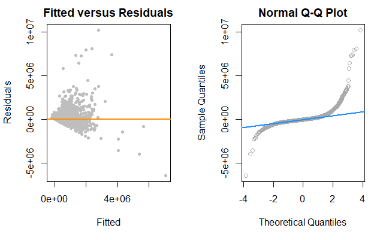

```r
qqnorm(resid(step.model1), main = "Normal Q-Q Plot", col = "darkgrey")
qqline(resid(step.model1), col = "dodgerblue", lwd = 2)
```

We can see that as the fitted value increases, the variance also increases quickly, and the residuals are not quite normally distributed. This calls for a variance stabilizing transformation.

## Examine the relationship between Price and numerical variables

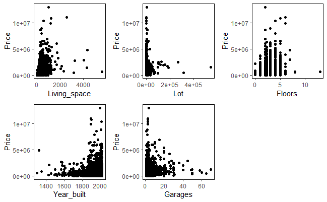

```r
space <- data_simple %>% ggplot(aes(x = Living_space, y = Price)) +
  geom_point()

lot <- data_simple %>% ggplot(aes(x = Lot, y = Price)) +
  geom_point()

floor <- data_simple %>% ggplot(aes(x = Floors, y = Price)) +
  geom_point()

year <- data_simple %>% ggplot(aes(x = Year_built, y = Price)) +
  geom_point()

gar <- data_simple %>% ggplot(aes(x = Garages, y = Price)) +
  geom_point()

gridExtra::grid.arrange(space, lot, floor, year, gar, nrow = 2)
```

We can immediately see a problem, which is that the relationships between these variables are not quite linear. We can try to solve this by creating a new dependent variable which transforms `Price` (e.g., natural logarithm, square root… ).

Does transforming `Price` to its natural logarithm help?

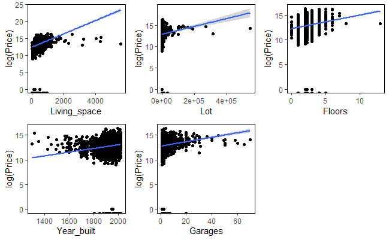

```r
space <- data_simple %>% ggplot(aes(x = Living_space, y = log(Price))) +
  geom_point() +
  geom_smooth(method='lm', formula= y~x)

lots  <- data_simple %>% ggplot(aes(x = Lot, y = log(Price))) +
  geom_point() +
  geom_smooth(method='lm', formula= y~x)

floor  <- data_simple %>% ggplot(aes(x = Floors , y = log(Price))) +
  geom_point() +
  geom_smooth(method='lm', formula= y~x)

year  <- data_simple %>% ggplot(aes(x = Year_built , y = log(Price))) +
  geom_point() +
  geom_smooth(method='lm', formula= y~x)

garage  <- data_simple %>% ggplot(aes(x = Garages , y = log(Price))) +
  geom_point() +
  geom_smooth(method='lm', formula= y~x)

grid.arrange(space , lots , floor , year , garage , nrow = 2)
```

It doesn’t really look like it does, so let’s use the Box-Cox method to determine the best transformations.

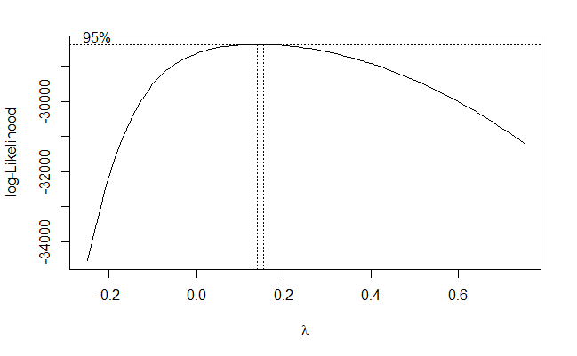

```r
library(MASS)
m1 <- lm(Price ~ ., data = train[train$Price > 0,])
boxcox(m1, plotit = TRUE, lambda = seq(-0.25, 0.75, by = 0.01))
```

lambda = 0.15 is close to the maximum and within the confidence interval, which suggests the following transformation could be applied to the response: (y^0.15 -1)/0.15

```r
bptest(m1_cox)
```

[output not shown]

```
    studentized Breusch-Pagan test

data:  m1_cox
BP = 339.44, df = 152, p-value = 2.382e-16
```

```r
sqrt(mean(m1_cox$residuals)^2)
```

```
[1] 1.0384e-17
```

## Predict test data

```r
t_final <- predict(wls_m1, newdata = test)
```

[output not shown]